# HW6

Mike Lehman

October 26, 2016

## Introduction

The goal of this assessment is to complete a market basket analysis through the use of association rule learning. Association rules identify patterns found in relationships among items found in sets, known as itemsets. Itemsets are simply sets of items that occur together. In summation, association rule learning is an unsupervised machine learning process that attempts to find patterns in the relationships among groups of items that occur together in a given data set.

Conveniently enough, to explore association rule learning through market basket analysis, we will use a data set comprised of grocery store transactions.

## Data Collection and Preparation

The data set used for this assessment is a simple .csv file that contains 9835 rows of sets of items. The sets of items consist of various combinations of grocery items (169 total) in generic categories such as: milk, yogurt, rolls. This is important to note as we will not have the level of data to perform highly granular rule mining for specific brands, flavors, or types of items. Instead we will be looking for patterns to be found in these generic categories of grocery items.

This type of transactional data is of a structure that would not translate well into a typical R data frame. When reading this data into a data frame, R will attempt to create the data frame dimensions based on the first row in the .csv file. This means that the data frame will have four columns even though our data set has many transactions with more of fewer items. Additionally, as the column values will be considered to have a relationship relative to the order in which they appear. That is, the same value (e.g. “coffee”) appearing in column one, will be treated differently than an instance of “coffee” that appears in column ten.

The solution to this problem is to load the data set into a sparse matrix. A sparse matrix is simply a two-dimensional data structure where each row represents a transaction, with the columns being a feature (item) and the cell value indicating whether or not the item appears. Because the structure is a sparse matrix, this indicates that most of the cells will be empty; however, this allows for any of the 169 possible features to appear in a given transaction.

To read the transactional data into R, we will use the read.transactions() function. We will also load the arules library which will be used to create our model:

```r
library(arules)
groceries <- read.transactions("groceries.csv", sep = ",")
summary(groceries)
```

```
## transactions as itemMatrix in sparse format with
##  9835 rows (elements/itemsets/transactions) and
##  169 columns (items) and a density of 0.02609146
##
## most frequent items:
##       whole milk other vegetables       rolls/buns             soda
##             2513             1903             1809             1715
##           yogurt          (Other)
##             1372            34055
##
## element (itemset/transaction) length distribution:
## sizes
##    1    2    3    4    5    6    7    8    9   10   11   12   13   14   15
## 2159 1643 1299 1005  855  645  545  438  350  246  182  117   78   77   55
##   16   17   18   19   20   21   22   23   24   26   27   28   29   32
##   46   29   14   14    9   11    4    6    1    1    1    1    3    1
##
##    Min. 1st Qu.  Median    Mean 3rd Qu.    Max.
##   1.000   2.000   3.000   4.409   6.000  32.000
##
## includes extended item information - examples:
##             labels
## 1 abrasive cleaner
## 2 artif. sweetener
## 3   baby cosmetics
```

From the summary output of the data, we can see our dimensions: 9835 rows (transactions) and 169 columns (items). The density of the sparse matrix (0.026) indicates that only 2.6% of the cells have actual values. Additionally, the output provides a list of the most frequent items and a useful table that tells us how many transactions have N number of items. For example, 2159 transactions have only one item, 1643 have two, and so on. Finally, there are the summary statistics for the number of items across all transactions.

The first five transactions show us how each individual transactions appears:

```r
inspect(groceries[1:5])
```

```
##     items
## [1] {citrus fruit,
##      margarine,
##      ready soups,
##      semi-finished bread}
## [2] {coffee,
##      tropical fruit,
##      yogurt}
## [3] {whole milk}
## [4] {cream cheese,
##      meat spreads,
##      pip fruit,
##      yogurt}
## [5] {condensed milk,
##      long life bakery product,
##      other vegetables,
##      whole milk}
```

Each transaction is an itemset of N number of items.

```r
itemFrequency(groceries[, 1:3])
```

```
## abrasive cleaner artif. sweetener   baby cosmetics
##     0.0035587189     0.0032536858     0.0006100661
```

The output from itemFrequency shows the support level, in this case, for the first three items (columns) in the data. The support level of an itemset refers to how frequently it appears in the data. That is, support(x) = count(x) / N where N is the number of transactions in the data.

In addition to the support level, association rules can also be evaluated using the confidence level. The confidence level is a measurement of the predictive power of a rule. Here we imply a rule to mean the content and order of items in an itemset. This tells us the proportion of transactions where the presence of item X indicates the presence of item Y. It is important to note that the order is relevant here, confidence of X -> Y is not the same as a confidence of Y -> X.

To further explore our data, the arules library includes functions to plot the frequency of items based on certain criteria.

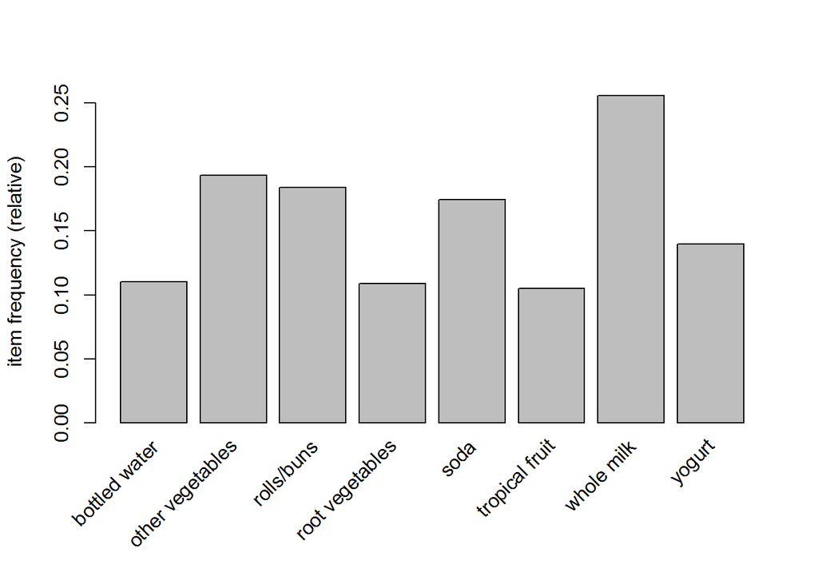

```r
itemFrequencyPlot(groceries, support = 0.1)
```

Here we have plotted the frequency of items with a minimum support level of 0.1. This means, plot the frequency of items where the item appears in at least 10% of the transactions.

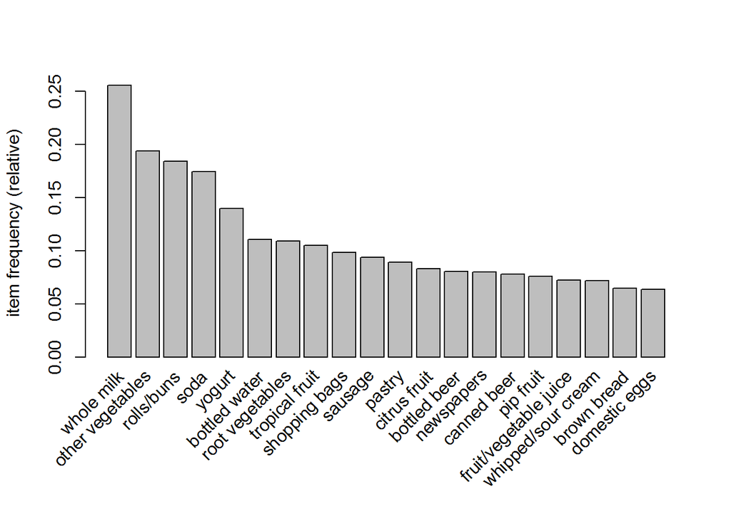

```r
itemFrequencyPlot(groceries, topN = 20)
```

These plots can be useful for exploring what items appear frequently, and can help to explore and improve results when assessing specific rules.

Finally, since our data is a sparse matrix, we can illustrate the distribution of the cells using image():

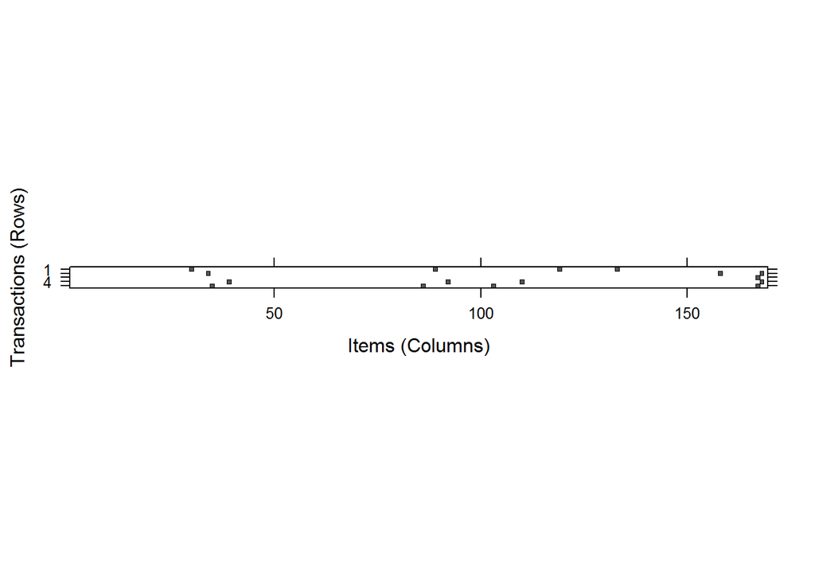

```r
image(groceries[1:5])
```

The plot shows the disbution of the items in the first five transactions in the data. We can illustrate other parts of the matrix as well:

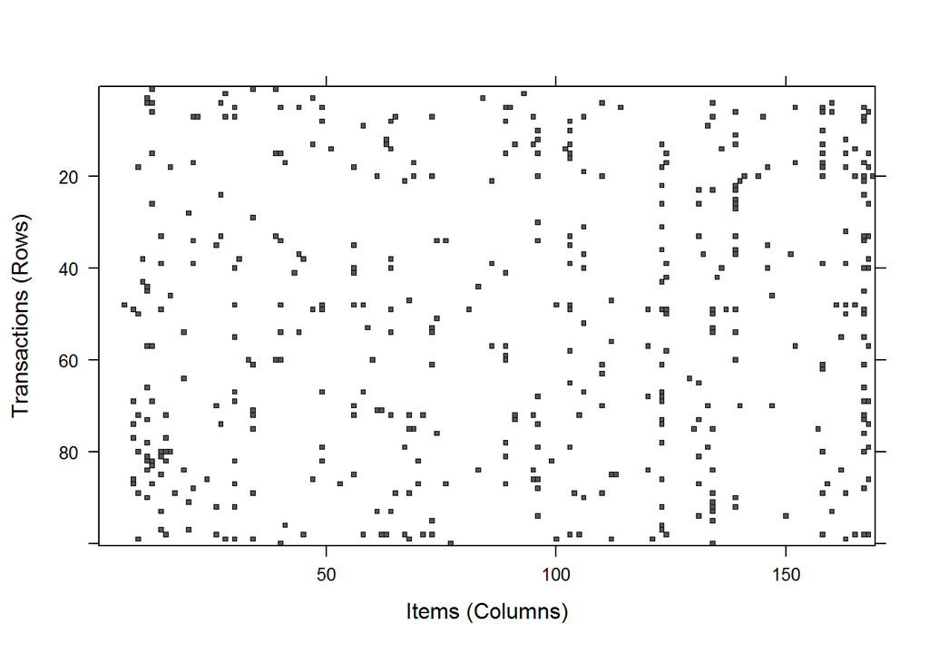

```r
image(sample(groceries, 100))
```

Here, we have taken a random sample of 100 transactions to see the distribution of items. Although these distribution images do not tell us anything about the actual rules that be mined from the data, they are useful for discerning certain patterns. For example, if there appears to be a pattern of filled cells that form a solid column for most of the column, that would tell us that there is an item that occurs freuqently across multiple transactions.

## Train Model

To train our model we will make use of the previously specified arules R library. Creating a set of association rules for our model requires only that we pass our sparse matrix of transactional data to the apriori method:

```r
apriori(groceries)
```

```
## Apriori
##
## Parameter specification:
##  confidence minval smax arem  aval originalSupport maxtime support minlen
##         0.8    0.1    1 none FALSE            TRUE       5     0.1      1
##  maxlen target   ext
##      10  rules FALSE
##
## Algorithmic control:
##  filter tree heap memopt load sort verbose
##     0.1 TRUE TRUE  FALSE TRUE    2    TRUE
##
## Absolute minimum support count: 983
##
## set item appearances ...[0 item(s)] done [0.00s].
## set transactions ...[169 item(s), 9835 transaction(s)] done [0.00s].
## sorting and recoding items ... [8 item(s)] done [0.00s].
## creating transaction tree ... done [0.00s].
## checking subsets of size 1 2 done [0.00s].
## writing ... [0 rule(s)] done [0.00s].
## creating S4 object  ... done [0.00s].
```

```
## set of 0 rules
```

Within the scope of association rule learning, the apriori algorithm works to first identify frequently occurring individual items in the data, then extending that process to larger and larger itemsets, so long as they appear frequently enough in the data.

Although building our model from the entire groceries data set without any parameters is possible, it is probably not ideal so we will want to assing our model to an object and specify a few parameters to ensure a more useful model:

```r
groceryrules <- apriori(groceries, parameter = list(support = 0.006, confidence = 0.25, minlen = 2))
```

```
## Apriori
##
## Parameter specification:
##  confidence minval smax arem  aval originalSupport maxtime support minlen
##        0.25    0.1    1 none FALSE            TRUE       5   0.006      2
##  maxlen target   ext
##      10  rules FALSE
##
## Algorithmic control:
##  filter tree heap memopt load sort verbose
##     0.1 TRUE TRUE  FALSE TRUE    2    TRUE
##
## Absolute minimum support count: 59
##
## set item appearances ...[0 item(s)] done [0.00s].
## set transactions ...[169 item(s), 9835 transaction(s)] done [0.00s].
## sorting and recoding items ... [109 item(s)] done [0.00s].
## creating transaction tree ... done [0.00s].
## checking subsets of size 1 2 3 4 done [0.00s].
## writing ... [463 rule(s)] done [0.00s].
## creating S4 object  ... done [0.00s].
```

```r
groceryrules
```

```
## set of 463 rules
```

For the groceryrules model, we specified minimum support and confidence levels to look for rules that only pertain to those items and itemsets which occur frequently enough in the data. For support we are looking for items that occur in 0.6% of the data.

Next, we will explore our model to evaluate the rules that were discovered and what we can learn from them.

## Evaluating Model Performance

```r
summary(groceryrules)
```

```
## set of 463 rules
##
## rule length distribution (lhs + rhs):sizes
##   2   3   4
## 150 297  16
##
##    Min. 1st Qu.  Median    Mean 3rd Qu.    Max.
##   2.000   2.000   3.000   2.711   3.000   4.000
##
## summary of quality measures:
##     support           confidence          lift
##  Min.   :0.006101   Min.   :0.2500   Min.   :0.9932
##  1st Qu.:0.007117   1st Qu.:0.2971   1st Qu.:1.6229
##  Median :0.008744   Median :0.3554   Median :1.9332
##  Mean   :0.011539   Mean   :0.3786   Mean   :2.0351
##  3rd Qu.:0.012303   3rd Qu.:0.4495   3rd Qu.:2.3565
##  Max.   :0.074835   Max.   :0.6600   Max.   :3.9565
##
## mining info:
##       data ntransactions support confidence
##  groceries          9835   0.006       0.25
```

The summary output of our rules object provides some important information about our model. First, we can see that our model discovered a total of 463 rules, and breaks down the number of rules based on their length for both left-hand and right-hand rules. We can see that there are 150 rules with two items, 297 with three items, and 16 with four items. The summary statistics for these rules follows.

After that we can see the summary statistics for the three indicators of rule quality: support, confidence, and lift. Since we specified minimum levels of support and confidence, we see those values as the minimum in the output.

In association rule learning, lift refers to the measure of performance that a learned rule has at predicting outcomes against a random subset of the model. Basically, how much better would a rule perform at predicting outcomes if it is applied to only a subset of the data. Higher lift means better performance.

We can inspect the first three rules in our model to see what type of rules were learned:

```r
inspect(groceryrules[1:3])
```

```
##     lhs                rhs               support     confidence lift
## [1] {potted plants} => {whole milk}      0.006914082 0.4000000  1.565460
## [2] {pasta}         => {whole milk}      0.006100661 0.4054054  1.586614
## [3] {herbs}         => {root vegetables} 0.007015760 0.4312500  3.956477
```

From the output we can see how our rules are structured. In the first column of the output is the left-hand side of the rule, with the second column containing the right-hand side of the rule. The left-hand side implies the right-hand side (e.g. potted plants implies whole milk). Lastly, the other columns contain the support, confidence, and lift for each of the rules.

Based on our understanding of lift, it makes sense to examine the rules with the best lift to identify which rules are most likely to extract some prior unknown knowledge from the data.

## Improving Model Performance

```r
inspect(sort(groceryrules, by = "lift")[1:5])
```

```
##     lhs                   rhs                      support confidence     lift
## [1] {herbs}            => {root vegetables}    0.007015760  0.4312500 3.956477
## [2] {berries}          => {whipped/sour cream} 0.009049314  0.2721713 3.796886
## [3] {other vegetables,
##      tropical fruit,
##      whole milk}       => {root vegetables}    0.007015760  0.4107143 3.768074
## [4] {beef,
##      other vegetables} => {root vegetables}    0.007930859  0.4020619 3.688692
## [5] {other vegetables,
##      tropical fruit}   => {pip fruit}          0.009456024  0.2634561 3.482649
```

The above command outputs the five rules with the best lift values in the model. Based on this output, we could likely use any of these rules for creating a new subset of the original rules to see if any greater insights can be gained. Since these rules have a high lift value, it can be inferred that these rules would likely translate and perform well against different subsets of data.

Since the rule: berries implies whipped/sour cream has a high lift, we can create a subset of our rules model to search for all rules which contain the term berries:

```r
berryrules <- subset(groceryrules, items %in% "berries")
inspect(berryrules)
```

```
##     lhs          rhs                  support     confidence lift
## [1] {berries} => {whipped/sour cream} 0.009049314 0.2721713  3.796886
## [2] {berries} => {yogurt}             0.010574479 0.3180428  2.279848
## [3] {berries} => {other vegetables}   0.010269446 0.3088685  1.596280
## [4] {berries} => {whole milk}         0.011794611 0.3547401  1.388328
```

Based on an inspection of the berryrules subset, we can see that the high lift rule from the original rule set scores best in terms of lift, but we can also see a new rule with a relatively high lift value: berries implies yogurt.

By applying a little bit of domain knowledge, let’s go back to our original groceryrules rule set to see what the other high lift rules were:

```r
inspect(sort(groceryrules, by = "lift")[1:5])
```

```
##     lhs                   rhs                      support confidence     lift
## [1] {herbs}            => {root vegetables}    0.007015760  0.4312500 3.956477
## [2] {berries}          => {whipped/sour cream} 0.009049314  0.2721713 3.796886
## [3] {other vegetables,
##      tropical fruit,
##      whole milk}       => {root vegetables}    0.007015760  0.4107143 3.768074
## [4] {beef,
##      other vegetables} => {root vegetables}    0.007930859  0.4020619 3.688692
## [5] {other vegetables,
##      tropical fruit}   => {pip fruit}          0.009456024  0.2634561 3.482649
```

It appears that “other vegetables” occur quite frequently in the left-hand side of several of the top five rules sorted by lift. From this, let’s create a subset based on this information and see what rules we can discover:

```r
vegrules <- subset(groceryrules, items %in% "other vegetables")
inspect(sort(vegrules, by = "lift")[1:10])
```

```
##      lhs                    rhs                   support confidence     lift
## [1]  {other vegetables,
##       tropical fruit,
##       whole milk}        => {root vegetables} 0.007015760  0.4107143 3.768074
## [2]  {beef,
##       other vegetables}  => {root vegetables} 0.007930859  0.4020619 3.688692
## [3]  {other vegetables,
##       tropical fruit}    => {pip fruit}       0.009456024  0.2634561 3.482649
## [4]  {other vegetables,
##       pip fruit}         => {tropical fruit}  0.009456024  0.3618677 3.448613
## [5]  {citrus fruit,
##       other vegetables}  => {root vegetables} 0.010371124  0.3591549 3.295045
## [6]  {other vegetables,
##       whole milk,
##       yogurt}            => {tropical fruit}  0.007625826  0.3424658 3.263712
## [7]  {other vegetables,
##       whole milk,
##       yogurt}            => {root vegetables} 0.007829181  0.3515982 3.225716
## [8]  {other vegetables,
##       tropical fruit,
##       whole milk}        => {yogurt}          0.007625826  0.4464286 3.200164
## [9]  {other vegetables,
##       rolls/buns,
##       whole milk}        => {root vegetables} 0.006202339  0.3465909 3.179778
## [10] {frozen vegetables,
##       other vegetables}  => {root vegetables} 0.006100661  0.3428571 3.145522
```

Here we see the top ten rules with “other vegetables” in the left-hand side of the rule. It is quite apparent that in many cases, a purchase of “other vegetables” frequently implies a purchase of “root vegetables”, regardless of the combination of items that includes “other vegetables.”

This may not be the most useful insight, as these similar produce purchases are probably likely already known or inferred, but it is worth considering that a purchase of one class of vegetable inevitably leads to the purchase of other classes.

Going back to our original rule set, “whole milk” is an item that appears in only one of the top five rules sorted by lift, but this seems like an item that would be purchased based on intuition alone. Let’s create a new subset to examine transactions where “whole milk” occurs in only the left-hand side of the transaction to see what are the strongest rules where “whole milk” implies another purchase:

```r
milkrules <- subset(groceryrules, lhs %in% "whole milk")
inspect(sort(milkrules, by = "lift")[1:10])
```

```
##      lhs                   rhs                    support confidence     lift
## [1]  {other vegetables,
##       tropical fruit,
##       whole milk}       => {root vegetables}  0.007015760  0.4107143 3.768074
## [2]  {beef,
##       whole milk}       => {root vegetables}  0.008032537  0.3779904 3.467851
## [3]  {other vegetables,
##       whole milk,
##       yogurt}           => {tropical fruit}   0.007625826  0.3424658 3.263712
## [4]  {other vegetables,
##       whole milk,
##       yogurt}           => {root vegetables}  0.007829181  0.3515982 3.225716
## [5]  {other vegetables,
##       tropical fruit,
##       whole milk}       => {yogurt}           0.007625826  0.4464286 3.200164
## [6]  {other vegetables,
##       rolls/buns,
##       whole milk}       => {root vegetables}  0.006202339  0.3465909 3.179778
## [7]  {root vegetables,
##       tropical fruit,
##       whole milk}       => {other vegetables} 0.007015760  0.5847458 3.022057
## [8]  {other vegetables,
##       root vegetables,
##       whole milk}       => {tropical fruit}   0.007015760  0.3026316 2.884091
## [9]  {cream cheese,
##       whole milk}       => {yogurt}           0.006609049  0.4012346 2.876197
## [10] {other vegetables,
##       whole milk}       => {root vegetables}  0.023182511  0.3097826 2.842082
```

It looks like a purchase of “whole milk” with any other combination of items, frequently leads to a purchase of root vegetables. Again, not necessarily a novel idea, but with more granualar data, we could potentially use these insights to discover new, unseen patterns in purchase trends.

Before wrapping up our examination of association rules using supermarket transaction data, let’s re-assign our rule sets and put them into a more useful format for export.

Writing our rules to a .csv format is something that would likely be beneficial in a case where we were to export our data and send to a marketing/sales team looking to implement new marketing or product strategies:

```r
write(groceryrules, file = "groceryrules.csv", sep = ",", quote = TRUE, row.names = FALSE)
groceryrules_df <- as(groceryrules, "data.frame")
str(groceryrules_df)
```

```
## 'data.frame':    463 obs. of  4 variables:
##  $ rules     : Factor w/ 463 levels "{baking powder} => {other vegetables}",..: 340 302 207 206 208 341 402 21 139 140 ...
##  $ support   : num  0.00691 0.0061 0.00702 0.00773 0.00773 ...
##  $ confidence: num  0.4 0.405 0.431 0.475 0.475 ...
##  $ lift      : num  1.57 1.59 3.96 2.45 1.86 ...
```

In addition to writing our rules data to a .csv file, we also created a data frame, which is a common data structure used in machine learning, and is somewhat more friendly to analysis than our rule classes.

Examining our data frame, casting our rule set as a data frame has resulted in a data frame that contains all 463 rules as one column of factor type with 463 values. The corresponding support, confidence, and lift values for each of the rules follow in the remaining columns.

## Conclusion

Association rule learners are quite powerful unsupervised machine learning techniques. The goal of any unsupervised machine learning technique is to extract useful insights into data where our desired outcome is not known. This is different from supervised machine learning techniques where we know the outcome for which we want to test (continuous or class) and are attempting to train a model to best learn from unseen data.

Association rule learners, like other unsupervised techniques, seek to extract insights from data without any training or preparation. The type of data used to perform such analysis and learning is transactional in nature and more closely resembles a data structure that is easier to read and interpret than other machine learning inputs.

Association rules can be understood as logical inferences and statements as opposed to complex mathematical models generated by tehcniques such as regression analysis and neural networks.

R Source